# ABSTRACT (ESA 2017): The draft genome of *Aphaenogaster* species from across a biogeographic gradient

M.K. Lau, A.M. Ellison, B. DeMarco, A. Nguyen, S.H. Cahan, N.J. Sanders, R. Dunn, C. Penick, N.J. Gotelli

### Abstract

**Background/Question/Methods**

Climate change rates are currently on track with the worst case scenarios, resulting in both terrestrial and aquatic ecosystem responses. Ants play important roles in ecosystems, including seed dispersal, which is a known factor in determining the rates of shifts in the range of many plant species. Recent field and laboratory climate experiments have demonstrated that ant communities in Eastern Forest ecosystems are likely to respond to climate change and that genetically based traits involved in heat and cold tolerance are likely to contribute to community dynamics. To address the need for detailed genetic information about the ant communities of this region, we conducted whole genome sequencing of six species of ants from the genus *Aphaenogaster*: including, *Aphaenogaster ashmeadi*, *A. floridana*, *A. fulva*, *A. miamiana*, *A. picea* and *A. rudis*. Whole colonies were collected from field sites in Eastern North America. Live individuals from each colony were isolated from debris, placed in 50 ml Falcon centrifuge tubes and immediately flash frozen in a -80 C freezer. DNA was extracted from each colony and sequenced on an Illumina HiSeq 2500 at the Broad Institute (Cambridge, MA). Raw sequences were processed to remove chimeric and contaminant sequences and assembled using ALLPATHS-LG with an additional post-assembly processing using Pilon, which reduced the gaps in coverage by 3.1% on average for an average reduction of 3.9 Mb of gaps.

**Results/Conclusion**

The genomes of all six species were successfully sequenced; and both raw sequences and the assembled genomes are currently stored at Harvard Forest (Petersham, MA). Assemblies and annotation are currently being processed for submission to NCBI’s genome database. All genomes showed high assembly quality (70% fragments mapped). Across all species average shortest contig length at 50% of the genome (i.e. *N50*) was 18864 bases; average assembly GC content was 38.18%; and average genome size was 471 Mb. Initial analyses using linear regression of *N50*, GC content and genome size revealed that none of these genomic characters varied significantly with latitude. These results provide a useful resource for examining the contribution of genetic variation underlying the response of these communities to climatic factors. Further work investigating the variation in genomic content (e.g. gene ontology or GO terms) and mapping of target coding regions from from previous experimental transcriptomic work on *Aphaenogaster* and other ants and social insects could improve predictions of the response of these ecosystems to climate change.

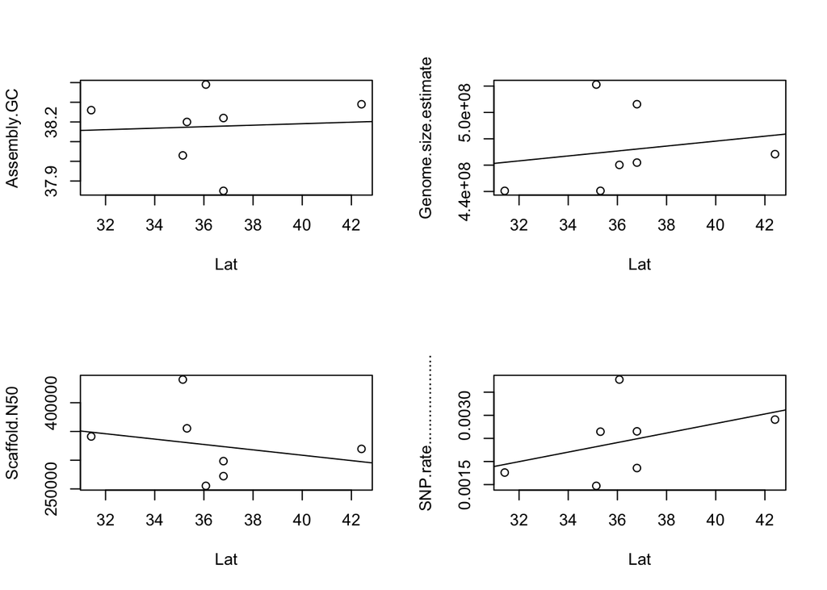

```r
par(mfrow=c(2,2))
plot(Assembly.GC~Lat,data=apg.dat)
abline(lm(Assembly.GC~Lat,data=apg.dat))
plot(Genome.size.estimate~Lat,data=apg.dat)
abline(lm(Genome.size.estimate~Lat,data=apg.dat))
plot(Scaffold.N50~Lat,data=apg.dat)
abline(lm(Scaffold.N50~Lat,data=apg.dat))
plot(SNP.rate....................~Lat,data=apg.dat)
abline(lm(SNP.rate....................~Lat,data=apg.dat))
```

```r
summary(lm(Assembly.GC~Lat,data=apg.dat))
```

```
##
## Call:
## lm(formula = Assembly.GC ~ Lat, data = apg.dat)
##
## Residuals:
##        6        3        5        4        1        2        7
##  0.10148  0.08937  0.21362  0.02656  0.04088 -0.32912 -0.14279
##
## Coefficients:
##              Estimate Std. Error t value Pr(>|t|)
## (Intercept) 38.038150   0.898447  42.338 1.39e-07 ***
## Lat          0.003831   0.024680   0.155    0.883
## ---
## Signif. codes:  0 '***' 0.001 '**' 0.01 '*' 0.05 '.' 0.1 ' ' 1
##
## Residual standard error: 0.1975 on 5 degrees of freedom
## Multiple R-squared:  0.004797,   Adjusted R-squared:  -0.1942
## F-statistic: 0.0241 on 1 and 5 DF,  p-value: 0.8827
```

```r
summary(lm(Genome.size.estimate~Lat,data=apg.dat))
```

```
##
## Call:
## lm(formula = Genome.size.estimate ~ Lat, data = apg.dat)
##
## Residuals:
##         6         3         5         4         1         2         7
## -21648217 -14429907 -10733293 -28942657 -10299778  34019025  52034827
##
## Coefficients:
##              Estimate Std. Error t value Pr(>|t|)
## (Intercept) 403105910  152263168   2.647   0.0456 *
## Lat           1878480    4182564   0.449   0.6721
## ---
## Signif. codes:  0 '***' 0.001 '**' 0.01 '*' 0.05 '.' 0.1 ' ' 1
##
## Residual standard error: 33470000 on 5 degrees of freedom
## Multiple R-squared:  0.03878,    Adjusted R-squared:  -0.1535
## F-statistic: 0.2017 on 1 and 5 DF,  p-value: 0.6721
```

```r
summary(lm(Contig.N50~Lat,data=apg.dat))
```

```
##
## Call:
## lm(formula = Contig.N50 ~ Lat, data = apg.dat)
##
## Residuals:
##       6       3       5       4       1       2       7
##  -442.4   677.1 -3247.2  1342.6 -2983.1   716.9  3936.1
##
## Coefficients:
##             Estimate Std. Error t value Pr(>|t|)
## (Intercept)  43850.8    12526.4   3.501   0.0173 *
## Lat           -688.8      344.1  -2.002   0.1017
## ---
## Signif. codes:  0 '***' 0.001 '**' 0.01 '*' 0.05 '.' 0.1 ' ' 1
##
## Residual standard error: 2753 on 5 degrees of freedom
## Multiple R-squared:  0.4449, Adjusted R-squared:  0.3338
## F-statistic: 4.007 on 1 and 5 DF,  p-value: 0.1017
```

```r
summary(lm(Scaffold.N50~Lat,data=apg.dat))
```

```
##
## Call:
## lm(formula = Scaffold.N50 ~ Lat, data = apg.dat)
##
## Residuals:
##      6      3      5      4      1      2      7
##  -7580  22261 -71686  24810 -25310 -51446 108951
##
## Coefficients:
##             Estimate Std. Error t value Pr(>|t|)
## (Intercept)   495946     298083   1.664    0.157
## Lat            -4682       8188  -0.572    0.592
##
## Residual standard error: 65520 on 5 degrees of freedom
## Multiple R-squared:  0.06138,    Adjusted R-squared:  -0.1263
## F-statistic: 0.327 on 1 and 5 DF,  p-value: 0.5922
```

```r
summary(lm(SNP.rate....................~Lat,data=apg.dat))
```

```
##
## Call:
## lm(formula = SNP.rate.................... ~ Lat, data = apg.dat)
##
## Residuals:
##          6          3          5          4          1          2
## -0.0001760 -0.0001649  0.0013554  0.0003068  0.0001605 -0.0006333
##          7
## -0.0008485
##
## Coefficients:
##               Estimate Std. Error t value Pr(>|t|)
## (Intercept) -1.308e-03  3.603e-03  -0.363    0.731
## Lat          1.033e-04  9.897e-05   1.043    0.345
##
## Residual standard error: 0.000792 on 5 degrees of freedom
## Multiple R-squared:  0.1788, Adjusted R-squared:  0.01459
## F-statistic: 1.089 on 1 and 5 DF,  p-value: 0.3445
```

### Methods

The complete genome of six species of Aphaenogaster were sequenced: Aphaenogaster ashmeadi, A. floridana, A. fulva, A. miamiana, A. picea and A. rudis. Whole colonies were collected from field sites in Eastern North America. Living individuals from each colony were isolated from debris, placed in 50 ml Falcon centrifuge tubes and immediately flash frozen in a -80 C freezer. DNA was extracted from each colony and sequenced on an Illumina HiSeq 2500 at the Broad Institute (Cambridge, MA). Raw sequences were processed to remove chimeric and contaminant sequences and assembled using ALLPATHS-LG with an additional post-assembly processing using Pilon to reduce gaps in coverage. The genomes of all six species were successfully sequenced with an average genome size of ~470 Mb. All genomes showed high assembly quality (70% fragments mapped). The additional Pilon processing of the assembly reduced the gaps in coverage by 3.1% on average for an average reduction of 3.9 Mb of gaps. Both raw and assembly data are currently housed at Harvard University on both a long-term storage server that is routinely backed-up and a solid state external hard drive stored at Harvard Forest (Petersham, MA). Additionally, after publication the assemblies will be submitted to NCBI’s genome database and linked to meta-data hosted by the Harvard Forest Data Archive.

### Sequencing Details

0. Sample locations
1. Genetics of ants and colonies
2. DNA extraction and quality
3. Library perparation
4. Genome assembly de novo (draft genome)
5. Assembly quality assessment and validation
6. Genome annotation (GO, KEGG, protein coding sequences)

### Genome Annotation

0. Gather target genes from other ant, insect and animal research
1. Mask repeat regions
2. Map target sequences
3. Compare translated sequences

Check out these software packages:

MAKER PASA WebApollo GMOD

### Analysis Outline

Basic analysis of genomic similarity across species Basic analysis of target genes

1. Heat stress response genes @Stanton-Geddes2016
2. Cold tolerance genes @Stanton-Geddes2016
3. Map transcripts onto genome and look for inter-specific variance @Stanton-Geddes2016
4. Immunity @Roux2014
5. Olfaction @Roux2014
6. Mitochondrial function @Roux2014
7. Social chromosome? @Brelsford2014